# Distance Spectrum of IEEE 802.11 Binary Convolutional Codes

Rethna Pulikkoonattu rethna@broadcom.com

**Abstract.** Binary convolutional coding (BCC) has been a cornerstone of the IEEE 802.11 wireless LAN standard since its inception, and it remains relevant today across the full generational arc from legacy 802.11a/g through Wi-Fi 6 (802.11ax) and into the forthcoming Wi-Fi 8 (802.11bn). Although LDPC codes now dominate high-throughput applications, BCC is mandatory for backward compatibility and continues to serve as the *default* FEC scheme in 20 MHz-only devices, IoT nodes, and other cost-sensitive deployments where LDPC decoder complexity is prohibitive. BCC at rate 1/2 is the coding scheme used throughout the packet preamble in every 802.11-compliant frame. The new *Enhanced Long Range* (ELR) packet format in 802.11bn also mandates rate-1/2 BCC for the data portion, reinforcing its continued importance.

The performance of BCC under Viterbi decoding is governed by the *distance spectrum* {(α<sub>d</sub>, β<sub>d</sub>)}<sub>d ≥ d<sub>free</sub></sub>. This note explains how to compute that spectrum exactly for the IEEE 802.11 mother code (rate 1/2, K=7, generators 133<sub>8</sub>/171<sub>8</sub>) and its three standard punctured derivatives (rates 2/3, 3/4, 5/6). Union-bound BEP and FER curves are derived for AWGN with BPSK/QPSK and Gray-coded M-QAM and validated against Monte Carlo simulation. Python, Julia, and C++ implementations are openly available at github.com/geekymode/bcc_spectrum.

# 1 Introduction

Despite the ubiquity of BCC in deployed IEEE 802.11 systems, a recurring obstacle when analysing or benchmarking its performance is the absence of a self-contained, publicly accessible resource that derives the distance spectrum from first principles and connects it cleanly to BER and FER bounds. Existing textbook treatments (Lin and Costello Jr. 2004; Proakis 2001; Viterbi and Omura 1979) cover the theory at varying levels of generality but do not provide spectrum tables, working code, or simulation-validated bound curves specific to the 802.11 puncture schedules. Standards documents (“IEEE Std 802.11-2020: IEEE Standard for Information Technology — Wireless LAN Medium Access Control (MAC) and Physical Layer (PHY) Specifications” 2021) state the generator polynomials and puncture matrices but say nothing about performance analysis.

Lin, S., and D. J. Costello Jr. 2004. *Error Control Coding*. 2nd ed. Upper Saddle River, NJ, USA: Pearson Prentice Hall.

Proakis, J. G. 2001. *Digital Communications*. 4th ed. New York, NY, USA: McGraw-Hill.

Viterbi, A. J., and J. K. Omura. 1979. *Principles of Digital Communication and Coding*. New York, NY, USA: McGraw-Hill.

This report attempts to fill that gap. The distance spectrum for each of the four standard rates is tabulated exactly; union-bound BEP and FER curves are derived and cross-validated against Monte Carlo simulation for both QPSK and 256-QAM; and the complete computational procedure is documented in pseudocode and three reference implementations (Python, Julia, C++). The source code is freely available at https://github.com/geekymode/bcc_spectrum (geekymode 2024).

geekymode. 2024. “bcc_spectrum: Distance Spectrum and Performance Bounds for IEEE 802.11 BCC.” GitHub repository. https://github.com/geekymode/bcc_spectrum.

# 2 The Mother Code

## 2.1 Encoder shift register

The 802.11 BCC is a *rate-$\frac{1}{2}$, constraint-length-$7$* convolutional encoder (Forney Jr. 1970) with generator polynomials
$$g_1 = 133_8 = (1,0,1,1,0,1,1), \qquad g_2 = 171_8 = (1,1,1,1,0,0,1).$$
In polynomial form, with $D$ the unit-delay operator,
$$g_1(D)=1+D^2+D^3+D^5+D^6, \qquad g_2(D)=1+D+D^2+D^3+D^6.$$
These generators were identified by Odenwalder (Odenwalder 1970) as maximising free distance at rate $\frac{1}{2}$, $K=7$, standardised by CCSDS (Consultative Committee for Space Data Systems 2013), and adopted in IEEE 802.11 (“IEEE Std 802.11-2020: IEEE Standard for Information Technology — Wireless LAN Medium Access Control (MAC) and Physical Layer (PHY) Specifications” 2021). At each clock cycle the encoder reads one input bit $u_n$, shifts it into a 6-stage register, and XORs selected taps to produce two output bits $(v_n^{(1)}, v_n^{(2)})$.

Forney Jr., G. D. 1970. “Convolutional Codes I: Algebraic Structure.” *IEEE Transactions on Information Theory* 16 (6): 720–38.

Odenwalder, J. P. 1970. “Optimal Decoding of Convolutional Codes.” PhD thesis, University of California, Los Angeles.

Consultative Committee for Space Data Systems. 2013. “Telemetry Channel Coding.” CCSDS 131.0-B-3. Washington, DC, USA: CCSDS.

IEEE 802.11 K=7 BCC shift-register encoder. Each D box is a unit-delay; ⊕ is mod-2 addition. The g₁=133₈ XOR chain runs above (taps 0,2,3,5,6); g₂=171₈ runs below (taps 0,1,2,3,6).

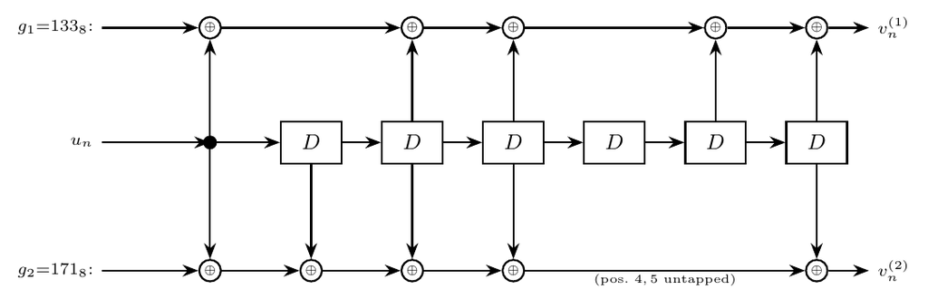

## 2.2 Trellis state

The encoder state $\sigma_n=(u_{n-1},\ldots,u_{n-6})\in\{0,\ldots,63\}$. A transition $\sigma\xrightarrow{u}\sigma'$ is (Forney Jr. 1970; Lin and Costello Jr. 2004):
$$\sigma'=\bigl((\sigma\ll 1)\;\&\;\texttt{0x3F}\bigr)\;|\;u, \qquad
v^{(k)}=\bigoplus_{i=0}^{6}g_k[i]\cdot r_i,\quad \mathbf{r}=(u,\sigma_0,\ldots,\sigma_5).$$
The trellis (Forney Jr. 1973) has 64 states, each with two outgoing branches.

Forney Jr., G. D. 1970. “Convolutional Codes I: Algebraic Structure.” *IEEE Transactions on Information Theory* 16 (6): 720–38.

Lin, S., and D. J. Costello Jr. 2004. *Error Control Coding*. 2nd ed. Upper Saddle River, NJ, USA: Pearson Prentice Hall.

Forney Jr., G. D. 1970. “Convolutional Codes I: Algebraic Structure.” *IEEE Transactions on Information Theory* 16 (6): 720–38. 1973. “The Viterbi Algorithm.” *Proceedings of the IEEE* 61 (3): 268–78.

Rate-1/2 trellis, 4 lowest states over n=0,…,7. Blue solid: u=0; red dashed: u=1. Edge labels (v⁽¹⁾v⁽²⁾) shown at first transition only.

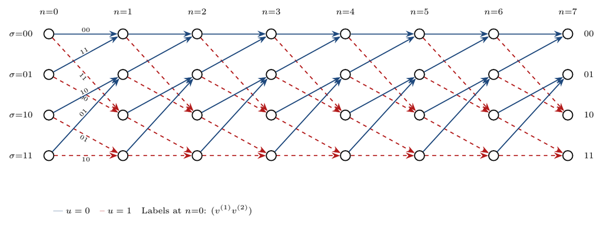

# 3 Puncturing and Puncture Matrices

Higher code rates are obtained by *puncturing*: periodically deleting output bits before transmission (Cain, Clark Jr., and Geist 1979; Yasuda, Kashiki, and Hirata 1984; Hagenauer 1988). A binary *puncture matrix* $\mathbf{P}$ specifies which bits survive (1 = transmit, 0 = delete). The serialised mask $\mathbf{p}$ is read column-by-column.

Cain, J. B., G. C. Clark Jr., and J. M. Geist. 1979. “Punctured Convolutional Codes of Rate $((n-1)/n)$ and Simplified Maximum Likelihood Decoding.” *IEEE Transactions on Information Theory* 25 (1): 97–100.

Yasuda, Y., K. Kashiki, and Y. Hirata. 1984. “High-Rate Punctured Convolutional Codes for Soft Decision Viterbi Decoding.” *IEEE Transactions on Communications* 32 (3): 315–19.

Hagenauer, J. 1988. “Rate-Compatible Punctured Convolutional Codes (RCPC Codes) and Their Applications.” *IEEE Transactions on Communications* 36 (4): 389–400.

## 3.1 Rate $\frac{1}{2}$ — unpunctured

$$\mathbf{P}_{1/2}=\begin{pmatrix}1\\1\end{pmatrix},\quad\mathbf{p}=(1,1).$$

## 3.2 Rate $\frac{2}{3}$

$$\mathbf{P}_{2/3}=\begin{pmatrix}1&1\\1&0\end{pmatrix},\quad\mathbf{p}=(1,1,1,0),\quad L=4.$$

## 3.3 Rate $\frac{3}{4}$

$$\mathbf{P}_{3/4}=\begin{pmatrix}1&1&0\\1&0&1\end{pmatrix},\quad\mathbf{p}=(1,1,1,0,0,1),\quad L=6.$$

## 3.4 Rate $\frac{5}{6}$

IEEE 802.11 puncture masks and free distances.

| Rate | Mask **p** | L | d_free |
| --- | --- | --- | --- |
| 1/2 | 11 | 2 | 10 |
| 2/3 | 1110 | 4 | 6 |
| 3/4 | 111001 | 6 | 5 |
| 5/6 | 1110011010 | 10 | 4 |

Rate-3/4 mask 111001 over two periods. Solid border: transmitted. Dashed: deleted.

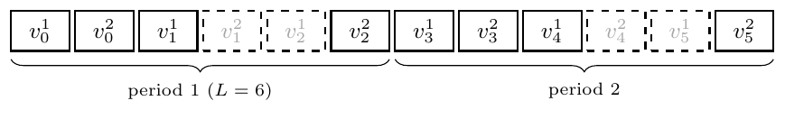

# 4 Distance Spectrum: Definitions

**Definition (Distance spectrum** (Lin and Costello Jr. 2004; Ryan and Lin 2009; Viterbi and Omura 1979)**).** The distance spectrum $\{(\alpha_d,\beta_d)\}_{d\geq d_\mathrm{free}}$: $\alpha_d$ counts error events at Hamming distance $d$ from the all-zero codeword; $\beta_d$ is the total input Hamming weight of those paths. The smallest $d$ with $\alpha_d>0$ is the *free distance* $d_\mathrm{free}$ (Viterbi 1967; Forney Jr. 1970).

Lin, S., and D. J. Costello Jr. 2004. *Error Control Coding*. 2nd ed. Upper Saddle River, NJ, USA: Pearson Prentice Hall.

Ryan, W. E., and S. Lin. 2009. *Channel Codes: Classical and Modern*. Cambridge, UK: Cambridge University Press.

Viterbi, A. J., and J. K. Omura. 1979. *Principles of Digital Communication and Coding*. New York, NY, USA: McGraw-Hill.

Viterbi, A. J. 1967. “Error Bounds for Convolutional Codes and an Asymptotically Optimum Decoding Algorithm.” *IEEE Transactions on Information Theory* 13 (2): 260–69.

Forney Jr., G. D. 1970. “Convolutional Codes I: Algebraic Structure.” *IEEE Transactions on Information Theory* 16 (6): 720–38.

# 5 BER Bounds from the Distance Spectrum

## 5.1 Union bound on bit-error probability

For the Viterbi decoder (Viterbi 1967; Forney Jr. 1973) over AWGN with BPSK, the pairwise error probability at Hamming distance $d$ is (Proakis 2001; Ryan and Lin 2009)
$$P_2(d)=Q\!\left(\sqrt{2d\,R_c\,\frac{E_b}{N_0}}\right).$$
The *union-bound bit-error probability* is (Viterbi 1967; Lin and Costello Jr. 2004)
$$P_b\;\lesssim\;\sum_{d=d_\mathrm{free}}^{D_{\max}}\beta_d\;Q\!\left(\sqrt{2d\,R_c\,\frac{E_b}{N_0}}\right). \tag{UB}$$

Viterbi, A. J. 1967. “Error Bounds for Convolutional Codes and an Asymptotically Optimum Decoding Algorithm.” *IEEE Transactions on Information Theory* 13 (2): 260–69.

Forney Jr., G. D. 1970. “Convolutional Codes I: Algebraic Structure.” *IEEE Transactions on Information Theory* 16 (6): 720–38. 1973. “The Viterbi Algorithm.” *Proceedings of the IEEE* 61 (3): 268–78.

Proakis, J. G. 2001. *Digital Communications*. 4th ed. New York, NY, USA: McGraw-Hill.

Ryan, W. E., and S. Lin. 2009. *Channel Codes: Classical and Modern*. Cambridge, UK: Cambridge University Press.

Viterbi, A. J. 1967. “Error Bounds for Convolutional Codes and an Asymptotically Optimum Decoding Algorithm.” *IEEE Transactions on Information Theory* 13 (2): 260–69.

Lin, S., and D. J. Costello Jr. 2004. *Error Control Coding*. 2nd ed. Upper Saddle River, NJ, USA: Pearson Prentice Hall.

## 5.2 Frame error rate

$$P_f\;\lesssim\;\sum_{d=d_\mathrm{free}}^{D_{\max}}\alpha_d\;Q\!\left(\sqrt{2d\,R_c\,\frac{E_b}{N_0}}\right). \tag{FER}$$

## 5.3 Single-term approximation

$$P_b\;\approx\;\beta_{d_\mathrm{free}}\;Q\!\left(\sqrt{2\,d_\mathrm{free}\,R_c\,\frac{E_b}{N_0}}\right).$$

Union-bound BEP and FER (10 spectrum terms, BPSK/AWGN).

[output not shown]

Forney Jr., G. D. 1970. “Convolutional Codes I: Algebraic Structure.” *IEEE Transactions on Information Theory* 16 (6): 720–38. 1973. “The Viterbi Algorithm.” *Proceedings of the IEEE* 61 (3): 268–78.

Heller, J. A., and I. M. Jacobs. 1971. “Viterbi Decoding for Satellite and Space Communication.” *IEEE Transactions on Communication Technology* 19: 835–48.

Proakis, J. G. 2001. *Digital Communications*. 4th ed. New York, NY, USA: McGraw-Hill.

BEP (left) and FER (right, K=1024) union bounds with simulation markers for all four IEEE 802.11 BCC rates over AWGN/QPSK. Lines: bounds (30 terms); dot-dashed+markers: Monte Carlo. Dotted black: uncoded BPSK.

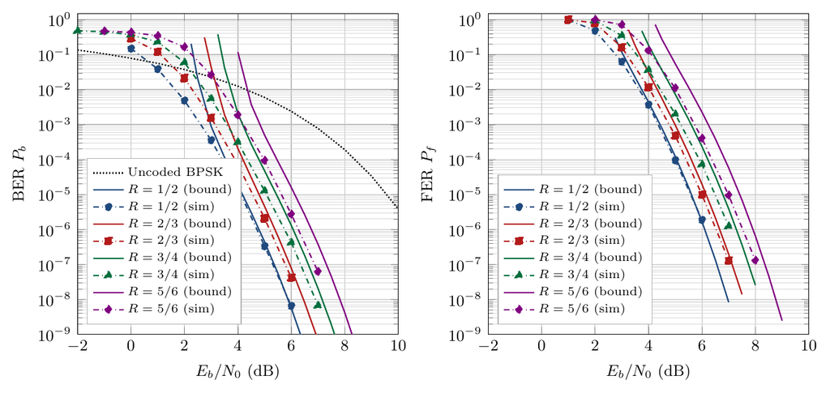

# 6 Bounds for Gray-Coded $M$-QAM

## 6.1 Channel model and penalty factor $\Delta_M$

Under the BICM model (Caire, Taricco, and Biglieri 1998), the pairwise error probability at distance $d$ becomes
$$P_2(d)\leq Q\!\left(\sqrt{2\,R_c\,d\,\Delta_M\,\frac{E_b}{N_0}}\right),\qquad
\Delta_M=\frac{3\,m}{2(M-1)},\quad m=\log_2 M,\quad M\geq 4.$$
For QPSK ($M=4$), $\Delta_M=1$, recovering the BPSK result.

Caire, Giuseppe, Giorgio Taricco, and Ezio Biglieri. 1998. “Bit-Interleaved Coded Modulation.” *IEEE Transactions on Information Theory* 44 (3): 927–46. https://doi.org/10.1109/18.669123.

Modulation penalty factor. Each QAM order step costs roughly 4–5 dB.

| M | m | Δ_M | Penalty (dB) |
| --- | --- | --- | --- |
| 4 | 2 | 1 | 0.0 |
| 16 | 4 | 2/5 = 0.4 | −4.0 |
| 64 | 6 | 2/14 ≈ 0.143 | −8.5 |
| 256 | 8 | 8/170 ≈ 0.047 | −13.3 |

## 6.2 Union bounds

Substituting $\Delta_M$ into the BPSK bounds replaces $E_b/N_0$ by $\Delta_M E_b/N_0$. Setting $\Delta_M=1$ recovers (UB) and (FER) exactly.

BEP union bounds for Gray-coded M-QAM (30 spectrum terms). Left: rate 1/2, varying M; dotted: uncoded references. Right: 256-QAM, all four rates; dot-dashed+markers: Monte Carlo for R=2/3 and R=3/4.

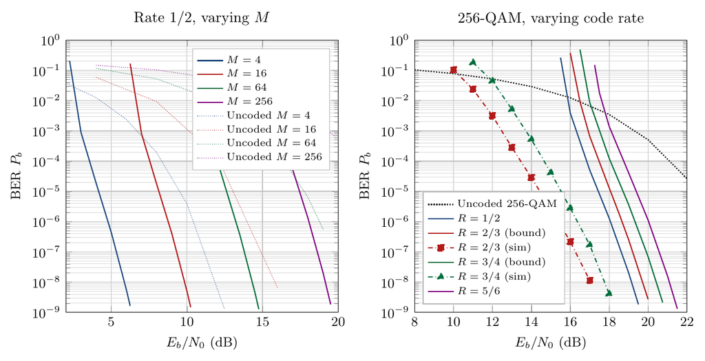

# 7 Augmented Trellis and Transfer Function

## 7.1 Why augment the state

For the unpunctured code the transfer function method uses a $64\times64$ state space (Lin and Costello Jr. 2004; Viterbi and Omura 1979). Puncturing makes branch weight *phase-dependent*; augmenting the state with the puncture phase $\phi\in\{0,\ldots,L-1\}$ converts this to a time-invariant problem (Hagenauer 1988). The augmented state is $(\sigma,\phi)$; for rate-3/4 ($L=6$) this gives $64\times6=384$ states.

Lin, S., and D. J. Costello Jr. 2004. *Error Control Coding*. 2nd ed. Upper Saddle River, NJ, USA: Pearson Prentice Hall.

Viterbi, A. J., and J. K. Omura. 1979. *Principles of Digital Communication and Coding*. New York, NY, USA: McGraw-Hill.

Hagenauer, J. 1988. “Rate-Compatible Punctured Convolutional Codes (RCPC Codes) and Their Applications.” *IEEE Transactions on Communications* 36 (4): 389–400.

Each branch carries weight $D^d N^u$ where $d=p_\phi v^{(1)}+p_{(\phi+1)\bmod L}v^{(2)}$. Branches partition into $\mathbf{E}$: START$\to\mathcal{S}$; $\mathbf{Q}$: $\mathcal{S}\to\mathcal{S}$; $\mathbf{R}$: $\mathcal{S}\to$START.

E/Q/R partition of the augmented trellis. The transfer function sums over all first-return paths from START to START.

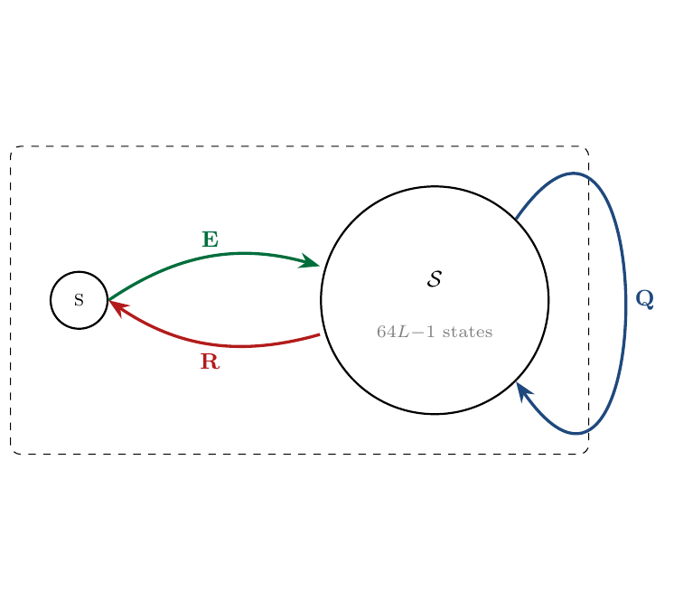

# 8 Computing the Transfer Function

The *first-return transfer polynomial* (Lin and Costello Jr. 2004; Viterbi and Omura 1979; Blahut 1983) is
$$T(D,N)=\mathbf{E}^\top(\mathbf{I}-\mathbf{Q})^{-1}\mathbf{R},\qquad
\alpha_d=[D^d]T(D,1),\quad\beta_d=[D^d]\tfrac{\partial T}{\partial N}\big|_{N=1}.$$

Lin, S., and D. J. Costello Jr. 2004. *Error Control Coding*. 2nd ed. Upper Saddle River, NJ, USA: Pearson Prentice Hall.

Viterbi, A. J., and J. K. Omura. 1979. *Principles of Digital Communication and Coding*. New York, NY, USA: McGraw-Hill.

Blahut, R. E. 1983. *Theory and Practice of Error Control Codes*. Reading, MA, USA: Addison-Wesley.

The Neumann series $(\mathbf{I}-\mathbf{Q})^{-1}\mathbf{R}=\sum_{k\geq0}\mathbf{Q}^k\mathbf{R}$ avoids matrix inversion (Lin and Costello Jr. 2004; Ryan and Lin 2009). Implementation uses: sparse polynomials `Dict[int→(count,weight)]`, combined multiply tracking both $\alpha$ and $\beta$ in one pass, and early termination when all terms exceed $d_{\max}$.

Lin, S., and D. J. Costello Jr. 2004. *Error Control Coding*. 2nd ed. Upper Saddle River, NJ, USA: Pearson Prentice Hall.

Ryan, W. E., and S. Lin. 2009. *Channel Codes: Classical and Modern*. Cambridge, UK: Cambridge University Press.

# 9 Pseudocode

**Algorithm: First-Return Spectrum for Punctured BCC**

**Input:** Puncture mask **p** ∈ {0,1}^L, max distance d_max  
**Output:** d_free, {α_d}, {β_d} for d ≤ d_max

1. For each augmented state (σ,φ) and u ∈ {0,1}:
   - Compute (σ′,φ′) and outputs (v⁽¹⁾, v⁽²⁾)
   - d ← p_φ v⁽¹⁾ + p_{(φ+1) mod L} v⁽²⁾; pol ← {d ↦ (1,u)}
   - Route pol to **E**, **Q**, or **R** based on src/dst vs. START
2. x ← 0; term ← **R**
3. Repeat:
   - x += term; term ← **Q** · term (sparse, truncate at d_max)
   - Until term = 0
4. T ← **E**^⊤ x; remove T[0]
5. d_free ← min(keys(T)); α_d ← T[d].count; β_d ← T[d].weight

*Note: The all-zero self-loop (START→START, u=0) is excluded.*

# 10 Full Distance Spectrum Tables

Rate 1/2, d_free=10. First 16 non-zero terms. Only even-d terms appear.

| d | α_d | β_d |
| --- | --- | --- |
| 10 | 11 | 36 |
| 12 | 38 | 211 |
| 14 | 193 | 1,404 |
| 16 | 1,331 | 11,633 |
| 18 | 7,275 | 77,433 |
| 20 | 40,406 | 502,690 |
| 22 | 234,969 | 3,322,763 |
| 24 | 1,337,714 | 21,292,910 |
| 26 | 7,594,819 | 134,365,911 |
| 28 | 43,375,588 | 843,425,871 |
| 30 | 247,339,453 | 5,245,283,348 |
| 32 | 1,409,277,901 | 32,372,937,519 |
| 34 | 8,034,996,288 | 198,723,833,069 |
| 36 | 45,808,756,116 | 1,213,657,958,889 |
| 38 | 261,128,775,464 | 7,378,557,447,583 |
| 40 | 1,488,634,502,286 | 44,686,304,667,721 |

Rate 2/3, d_free=6. First 15 non-zero terms. Puncturing introduces odd-d terms.

| d | α_d | β_d |
| --- | --- | --- |
| 6 | 1 | 3 |
| 7 | 16 | 70 |
| 8 | 48 | 285 |
| 9 | 158 | 1,276 |
| 10 | 642 | 6,160 |
| 11 | 2,435 | 27,128 |
| 12 | 9,174 | 117,019 |
| 13 | 34,705 | 498,860 |
| 14 | 131,585 | 2,103,891 |
| 15 | 499,608 | 8,784,123 |
| 16 | 1,893,179 | 36,328,084 |
| 17 | 7,172,729 | 149,215,136 |
| 18 | 27,191,646 | 609,374,214 |
| 19 | 103,077,011 | 2,475,565,587 |
| 20 | 390,696,502 | 10,011,487,814 |

Rate 3/4, d_free=5. First 15 non-zero terms.

| d | α_d | β_d |
| --- | --- | --- |
| 5 | 8 | 42 |
| 6 | 31 | 201 |
| 7 | 160 | 1,492 |
| 8 | 892 | 10,469 |
| 9 | 4,512 | 62,935 |
| 10 | 23,307 | 379,644 |
| 11 | 121,077 | 2,253,373 |
| 12 | 625,059 | 13,073,811 |
| 13 | 3,234,886 | 75,152,755 |
| 14 | 16,753,077 | 428,005,675 |
| 15 | 86,686,071 | 2,415,121,123 |
| 16 | 448,565,858 | 13,534,984,705 |
| 17 | 2,321,546,552 | 75,422,690,722 |
| 18 | 12,014,661,684 | 418,134,779,192 |
| 19 | 62,177,678,298 | 2,307,775,877,171 |

Rate 5/6, d_free=4. First 13 non-zero terms.

| d | α_d | β_d |
| --- | --- | --- |
| 4 | 14 | 92 |
| 5 | 69 | 528 |
| 6 | 654 | 8,694 |
| 7 | 4,996 | 79,453 |
| 8 | 39,699 | 792,114 |
| 9 | 315,371 | 7,375,573 |
| 10 | 2,507,890 | 67,884,974 |
| 11 | 19,921,920 | 610,875,423 |
| 12 | 158,275,483 | 5,427,275,376 |
| 13 | 1,257,455,600 | 47,664,215,639 |
| 14 | 9,990,453,938 | 414,847,451,604 |
| 15 | 79,372,452,075 | 3,583,040,670,062 |
| 16 | 630,602,872,400 | 30,748,409,619,146 |

# 11 Complexity and Correctness

**State space.** $64L$ augmented states; for $L\leq10$ at most $639\times639$. The Neumann iteration converges in milliseconds.

**Convergence.** $\mathbf{Q}^k\mathbf{R}$ has minimum polynomial degree $\geq k$, guaranteeing termination within $d_{\max}$ steps (Lin and Costello Jr. 2004; Viterbi and Omura 1979).

Lin, S., and D. J. Costello Jr. 2004. *Error Control Coding*. 2nd ed. Upper Saddle River, NJ, USA: Pearson Prentice Hall.

Viterbi, A. J., and J. K. Omura. 1979. *Principles of Digital Communication and Coding*. New York, NY, USA: McGraw-Hill.

**Validation.** Published reference values ($d_\mathrm{free}=10$, $\alpha_{10}=11$, $\beta_{10}=36$ for rate-1/2) (“IEEE Std 802.11-2020: IEEE Standard for Information Technology — Wireless LAN Medium Access Control (MAC) and Physical Layer (PHY) Specifications” 2021; Proakis 2001) are reproduced exactly by all three implementations.

Proakis, J. G. 2001. *Digital Communications*. 4th ed. New York, NY, USA: McGraw-Hill.

# Method: Augmented-Trellis First-Return Series

The **augmented-trellis first-return series expansion** combines three ideas. *Augmented trellis*: the encoder state is extended by a puncture-phase coordinate (Hagenauer 1988; Yasuda, Kashiki, and Hirata 1984), converting a phase-dependent problem into a time-invariant graph. *First-return*: only paths from START back to START are enumerated — exactly the error events entering Viterbi’s union bound (Viterbi 1967). *Series expansion*: the Neumann series $(I-Q)^{-1}=\sum_k Q^k$ avoids explicit matrix inversion (Lin and Costello Jr. 2004; Blahut 1983).

Hagenauer, J. 1988. “Rate-Compatible Punctured Convolutional Codes (RCPC Codes) and Their Applications.” *IEEE Transactions on Communications* 36 (4): 389–400.

Yasuda, Y., K. Kashiki, and Y. Hirata. 1984. “High-Rate Punctured Convolutional Codes for Soft Decision Viterbi Decoding.” *IEEE Transactions on Communications* 32 (3): 315–19.

Viterbi, A. J. 1967. “Error Bounds for Convolutional Codes and an Asymptotically Optimum Decoding Algorithm.” *IEEE Transactions on Information Theory* 13 (2): 260–69.

Lin, S., and D. J. Costello Jr. 2004. *Error Control Coding*. 2nd ed. Upper Saddle River, NJ, USA: Pearson Prentice Hall.

Blahut, R. E. 1983. *Theory and Practice of Error Control Codes*. Reading, MA, USA: Addison-Wesley.

This is closely related to the transfer function method of Lin & Costello (Lin and Costello Jr. 2004), Viterbi & Omura (Viterbi and Omura 1979), Blahut (Blahut 1983), and Ryan & Lin (Ryan and Lin 2009). Phase augmentation for punctured codes is due to Hagenauer (Hagenauer 1988) and Yasuda et al. (Yasuda, Kashiki, and Hirata 1984); the free-distance optimality of $133_8/171_8$ was established by Odenwalder (Odenwalder 1970) and documented by Heller & Jacobs (Heller and Jacobs 1971).

Lin, S., and D. J. Costello Jr. 2004. *Error Control Coding*. 2nd ed. Upper Saddle River, NJ, USA: Pearson Prentice Hall.

Viterbi, A. J., and J. K. Omura. 1979. *Principles of Digital Communication and Coding*. New York, NY, USA: McGraw-Hill.

Blahut, R. E. 1983. *Theory and Practice of Error Control Codes*. Reading, MA, USA: Addison-Wesley.

Ryan, W. E., and S. Lin. 2009. *Channel Codes: Classical and Modern*. Cambridge, UK: Cambridge University Press.

Hagenauer, J. 1988. “Rate-Compatible Punctured Convolutional Codes (RCPC Codes) and Their Applications.” *IEEE Transactions on Communications* 36 (4): 389–400.

Yasuda, Y., K. Kashiki, and Y. Hirata. 1984. “High-Rate Punctured Convolutional Codes for Soft Decision Viterbi Decoding.” *IEEE Transactions on Communications* 32 (3): 315–19.

Odenwalder, J. P. 1970. “Optimal Decoding of Convolutional Codes.” PhD thesis, University of California, Los Angeles.

Heller, J. A., and I. M. Jacobs. 1971. “Viterbi Decoding for Satellite and Space Communication.” *IEEE Transactions on Communication Technology* 19: 835–48.

# Spectrum Toolkit

Three independent implementations, all producing bit-identical results.  
Source: https://github.com/geekymode/bcc_spectrum (geekymode 2024).

geekymode. 2024. “bcc_spectrum: Distance Spectrum and Performance Bounds for IEEE 802.11 BCC.” GitHub repository. https://github.com/geekymode/bcc_spectrum.

- `python/bcc_spectrum.py` — Pure Python 3, stdlib only.
- `julia/bcc_spectrum.jl` — Julia with typed dicts and in-place polynomial arithmetic.
- `cpp/bcc_spectrum.cpp` + `bcc_spectrum.h` — C++17 library with command-line driver.

## Python

```python
# Run from terminal: d_max=30, show 5 terms per rate
python3 python/bcc_spectrum.py 30 5

# Library API
from python.bcc_spectrum import compute_spectrum, PUNCTURE_MASKS
dfree, alpha, beta = compute_spectrum(PUNCTURE_MASKS["1/2"], d_max=60)
print(dfree, alpha[10], beta[10])   # 10  11  36

# Custom puncture mask
my_mask = [1, 1, 0, 1, 1, 0]
dfree, alpha, beta = compute_spectrum(my_mask, d_max=80)
```

## Julia

```julia
# Run from terminal
julia julia/bcc_spectrum.jl 30 5

# REPL / script
include("julia/bcc_spectrum.jl")
dfree, alpha, beta = compute_spectrum(PUNCTURE_MASKS["3/4"], 60)
println(dfree, "  ", alpha[5], "  ", beta[5])   # 5  8  42
```

## C++

```cpp
// Build
g++ -std=c++17 -O2 -o bcc_spectrum cpp/bcc_spectrum.cpp cpp/main.cpp

// Run from terminal
./bcc_spectrum 30 5

// Library API
#include "bcc_spectrum.h"
auto [dfree, alpha, beta] = bcc::compute_spectrum(bcc::mask_half(), 60);
// dfree=10  alpha[10]=11  beta[10]=36
```

## Sample output

```
IEEE 802.11 BCC Distance Spectrum  |  K=7, generators 133_8/171_8
d_max=30, 5 terms per rate
============================================================
Rate 1/2  (puncture period=2)   d_free=10
   d       alpha_d        beta_d
  10            11            36
  12            38           211
  14           193         1,404
  16         1,331        11,633
  18         7,275        77,433

Rate 2/3  (puncture period=4)   d_free=6
   d       alpha_d        beta_d
   6             1             3
   7            16            70
   8            48           285
   9           158         1,276
  10           642         6,160

Rate 3/4  (puncture period=6)   d_free=5
   d       alpha_d        beta_d
   5             8            42
   6            31           201
   7           160         1,492
   8           892        10,469
   9         4,512        62,935

Rate 5/6  (puncture period=10)  d_free=4
   d       alpha_d        beta_d
   4            14            92
   5            69           528
   6           654         8,694
   7         4,996        79,453
   8        39,699       792,114
```